# Datenanalyse mit R

28 März 2019

## Datenanalyse mit R

Die Möglichkeiten der Datenanalyse mit R sind Dank einer Vielzahl an Paketen Legion

Je nach Methode ist der benötigte Input unterschiedlich - *tidyverse hilft*

Auch Output variiert - nicht immer wird alles ausgegeben (checke `values` mit `help()`)

Methoden sind nur Tools - Auswahl und Ergebnisinterpretation entscheidet AnwenderIn

Deskriptive Statisiken am besten mittels `dplyr::summarize()` (siehe Tag 1)

## Werbung in eigener Sache

Android-App: [Statistik-Hilfe](https://play.google.com/store/apps/details?id=b.piskernik.statisticshelper&hl=de)

Entscheidungsbaum

Anleitungen für SPSS und R

Alternativen und ähnliche Verfahren

## Kenne deine Daten bevor du sie analysierst

## DataExplorer

Vor jeder Analyse sollten Daten genau inspiziert werden.

Das Paket `DataExplorer` hilft.

```r
DataExplorer::introduce(weather) %>%
  t() ## t() transponiert = kippt Tabelle
```

```
##                         [,1]
## rows                   26115
## columns                   15
## discrete_columns           2
## continuous_columns        13
## all_missing_columns        0
## total_missing_values   23974
## complete_rows           4980
## total_observations    391725
## memory_usage         2929424
```

## DataExplorer::introduce - grafisch

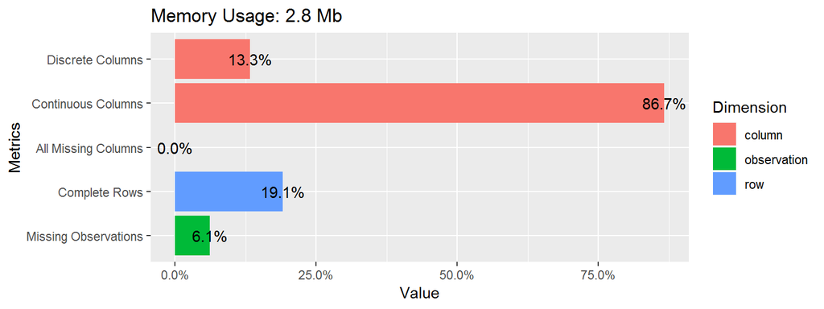

```r
DataExplorer::plot_intro(weather)
```

## Missings Überblick

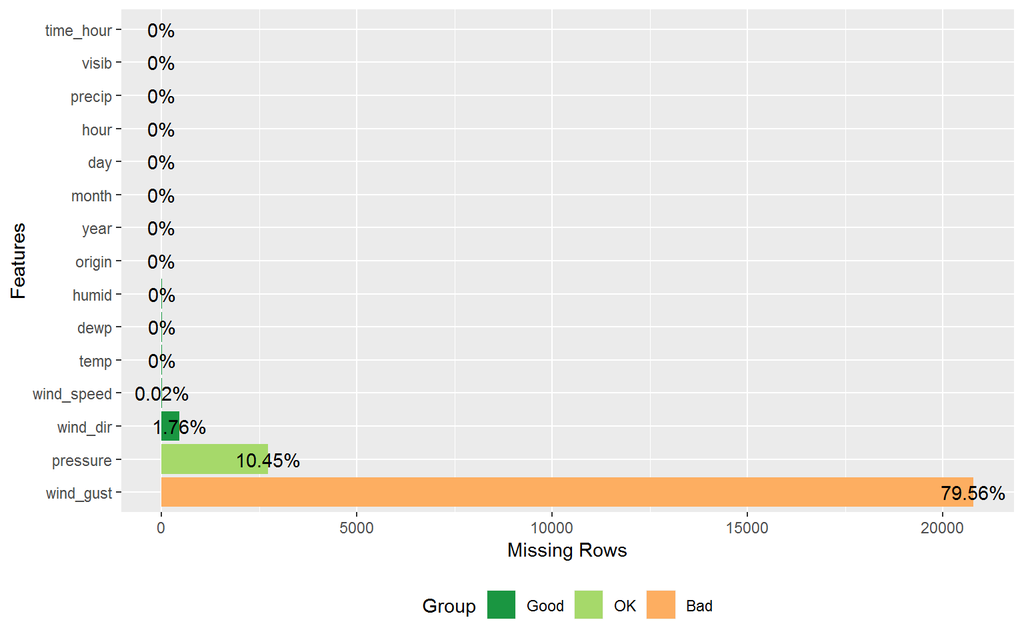

```r
DataExplorer::plot_missing(weather)
```

## Kategoriale Daten

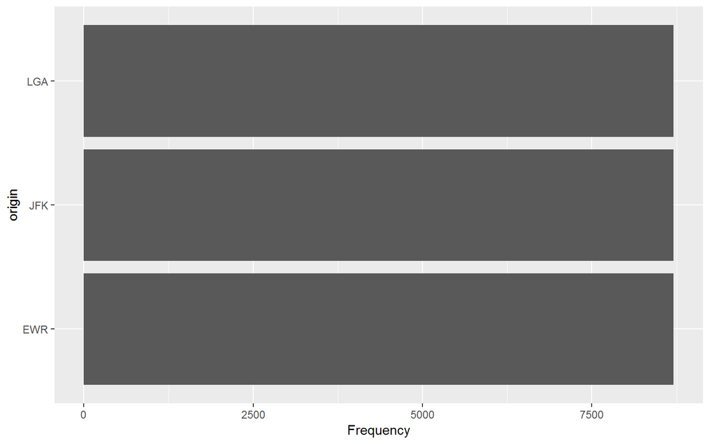

```r
DataExplorer::plot_bar(weather)
```

## Kontinuierliche Daten

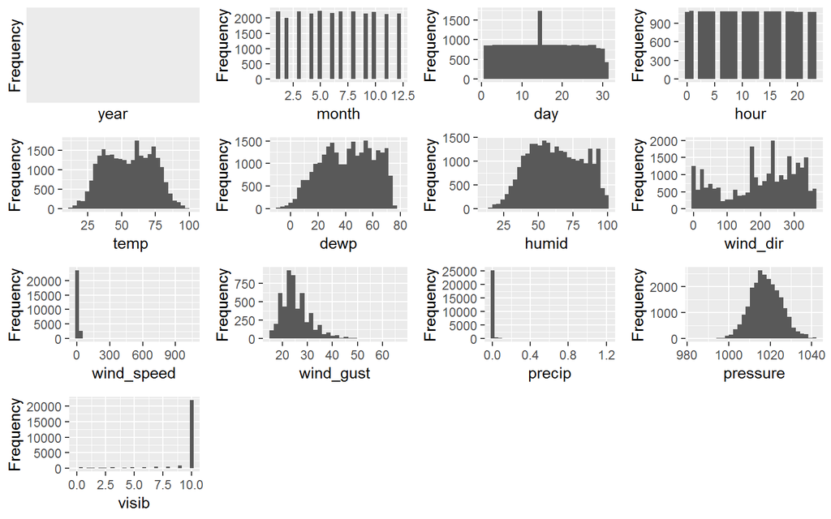

```r
DataExplorer::plot_histogram(weather)
```

## Normalverteilt? Checke QQ-Plots!

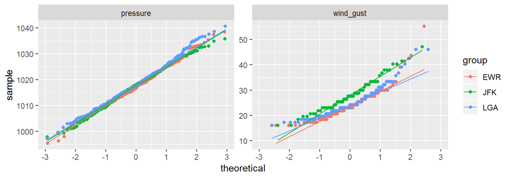

```r
weather %>%
  select(origin, wind_gust, pressure) %>%
  DataExplorer::plot_qq(by = "origin", sampled_rows = 1000L)
```

## Korrelationen

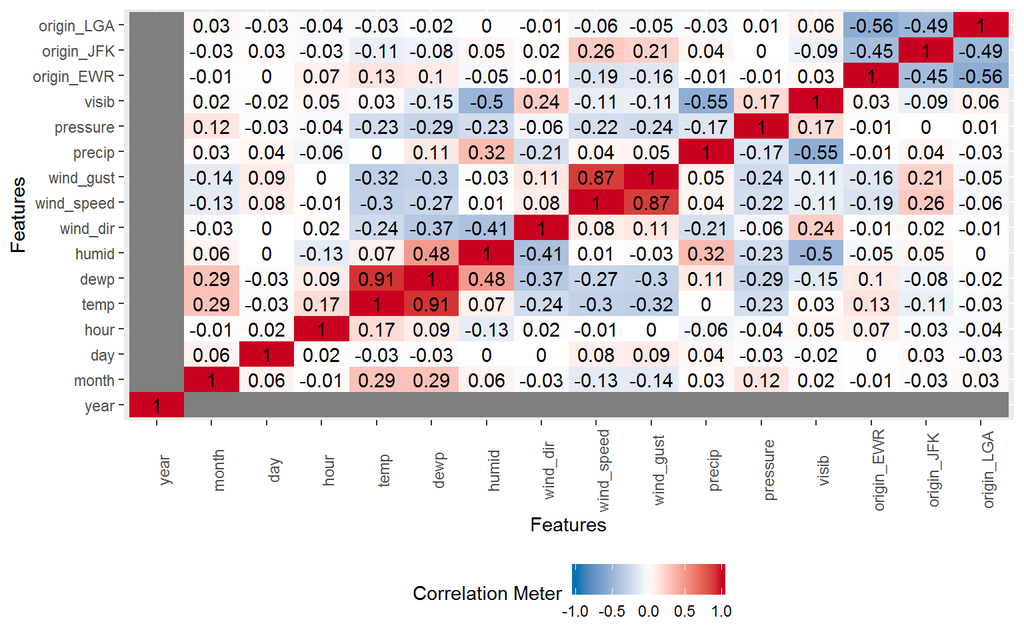

```r
DataExplorer::plot_correlation(na.omit(weather))
```

## Korrekturen

Korrekturen/Änderungen notwendig?

Nutze `tidyverse` (siehe Tag 1)!

ZB:

```r
weather_cor <- weather %>%
  mutate(
    wind_speed = if_else(wind_speed > 60, NA_real_, wind_speed)
  )
```

## Formula

## Formula

R Pakete unterscheiden sich stark voneinander

**ABER**: Viele Pakete nutzen *einheitlichen Aufbau* um den zu modellierenden *Zusammenhang zwischen AV und UVs* zu beschreiben.

Allgemeine Form:

```
AV ~
UV-Struktur
```

Kann für Wiedverwendung und Veränderung gespeichert werden

```r
h <- formula("y ~ x1 + x2")
```

## Formeloperatoren

| Operator | Funktion |
| --- | --- |
| ~ | Trennung zw. AV und UV |
| + | fügt weiteren Ausdruck hinzu |
| - | entfernt Ausdruck (aus gespeicherte Formeln) |
| * | fügt Ausdrücke links und rechts hinzu & deren Wechselwirkungen |
| : | fügt nur Wechselwirkung hinzu |
| . | fügt alle Variablen hinzu |

## Lineare Modelle

## lm()

Die Basis-Funktion zur Analyse *linearer Modelle* ist `lm()`

Eine einfache Regression:

```r
lm(wind_speed ~ pressure, data=weather_cor)
```

```
##
## Call:
## lm(formula = wind_speed ~ pressure, data = weather_cor)
##
## Coefficients:
## (Intercept)     pressure
##    162.9594      -0.1499
```

## Regression mit Wechselwirkungen

```r
with(
  ## Daten
  weather_cor %>%
    mutate_if(is.numeric, scale),
  ## Ausdruck
  lm(wind_speed ~ pressure*humid)
)
```

```
##
## Call:
## lm(formula = wind_speed ~ pressure * humid)
##
## Coefficients:
##    (Intercept)        pressure           humid  pressure:humid
##       -0.07518        -0.25973        -0.37994         0.02042
```

## Noch mehr Wechselwirkungen

```r
with(
  weather_cor %>%
    mutate_if(is.numeric, scale),
  lm(wind_speed ~ pressure*origin)
)
```

```
##
## Call:
## lm(formula = wind_speed ~ pressure * origin)
##
## Coefficients:
##        (Intercept)            pressure           originJFK
##           -0.21919            -0.20795             0.37277
##          originLGA  pressure:originJFK  pressure:originLGA
##            0.21111            -0.02521             0.04811
```

Beachte: Kategoriale Variablen müssen `chr` oder `factor` sein!

## Übung

Modell das `wind_speed` durch `pressure`, `humid` und `origin` sowie deren 2-fach Wechselwirkungen beschreibt

**Lösung:**

```
##
## Call:
## lm(formula = wind_speed ~ pressure * humid + pressure * origin +
##     humid * origin)
##
## Coefficients:
##        (Intercept)            pressure               humid
##          -0.266150           -0.277949           -0.424369
##          originJFK           originLGA      pressure:humid
##           0.433614            0.159047            0.025818
## pressure:originJFK  pressure:originLGA     humid:originJFK
##          -0.035915            0.074905           -0.008654
##    humid:originLGA
##           0.110446
```

## `summary()` für umfangreichere Ergebnisdarstellung

```r
modell1 <- lm(wind_speed ~ pressure*origin, data = weather_cor)

modell1 %>% summary()
```

```
##
## Call:
## lm(formula = wind_speed ~ pressure * origin, data = weather_cor)
##
## Residuals:
##      Min       1Q   Median       3Q      Max
## -14.1341  -3.6638  -0.5173   3.2629  26.1195
##
## Coefficients:
##                      Estimate Std. Error t value Pr(>|t|)
## (Intercept)        169.692163   8.388117  20.230  < 2e-16 ***
## pressure            -0.157627   0.008241 -19.127  < 2e-16 ***
## originJFK           21.548240  11.798571   1.826  0.06781 .
## originLGA          -35.931186  11.842443  -3.034  0.00242 **
## pressure:originJFK  -0.019109   0.011590  -1.649  0.09921 .
## pressure:originLGA   0.036466   0.011636   3.134  0.00173 **
## ---
## Signif. codes:  0 '***' 0.001 '**' 0.01 '*' 0.05 '.' 0.1 ' ' 1
##
## Residual standard error: 5.373 on 23376 degrees of freedom
##   (2733 observations deleted due to missingness)
## Multiple R-squared:  0.06488,    Adjusted R-squared:  0.06468
## F-statistic: 324.4 on 5 and 23376 DF,  p-value: < 2.2e-16
```

## plot()

Die meisten Analyseprozeduren in R haben eine eigene Plot-Funktion, welche die Ergebnisse methodenabhängig visualisiert.

Aufruf erfolgt spezifisch mittels

`plot.methodenname(Modell)`

oder generisch mittels

`plot(Modell)`

`plot.lm()` hilft die Voraussetzungen zu überprüfen

## Linearität

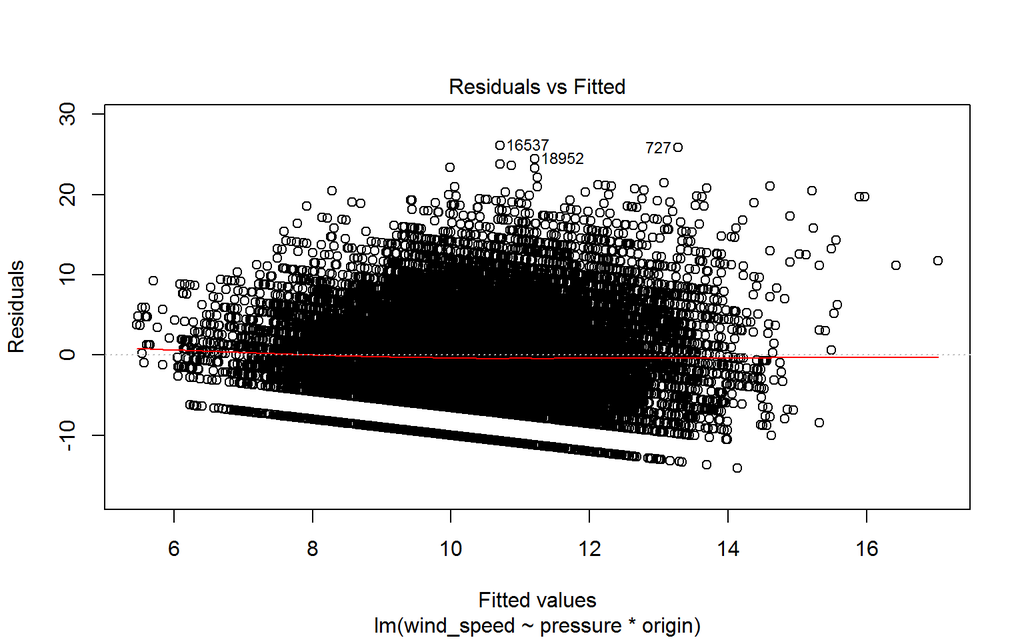

```r
plot(modell1, which=1)
```

## Normalverteilung

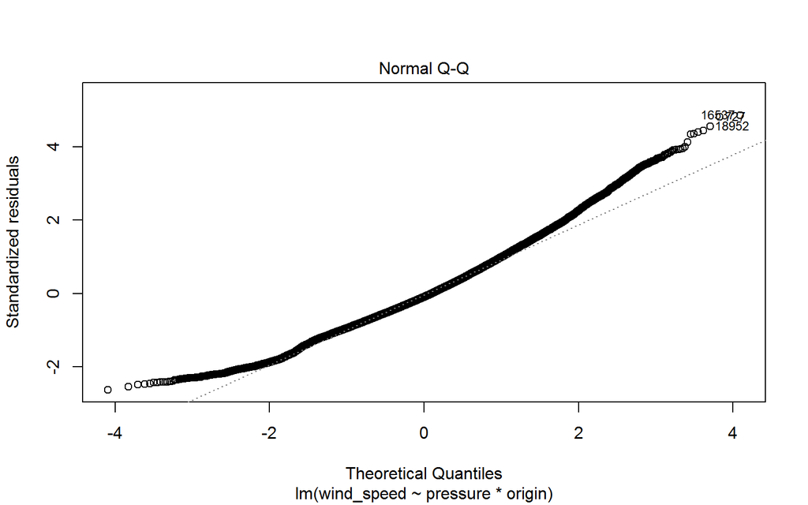

```r
plot(modell1, which=2)
```

## Homoskedastizität

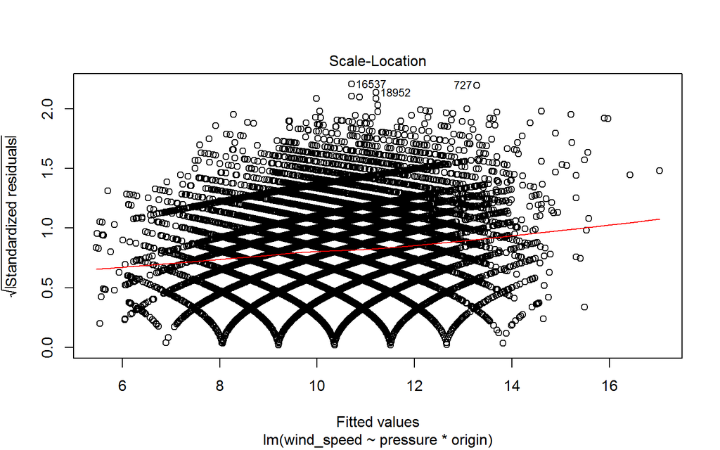

```r
plot(modell1, which=3)
```

## Frage

Welche Voraussetzung fehlt noch?

Gibt es für Unabhängigkeit der Residuen auch einen Plot?

## Ergebnis als AN(C)OVA

```r
modell1 %>%
  anova()
```

```
## Analysis of Variance Table
##
## Response: wind_speed
##                    Df Sum Sq Mean Sq  F value    Pr(>F)
## pressure            1  28969 28968.5 1003.556 < 2.2e-16 ***
## origin              2  17162  8581.0  297.272 < 2.2e-16 ***
## pressure:origin     2    686   343.2   11.888 6.915e-06 ***
## Residuals       23376 674768    28.9
## ---
## Signif. codes:  0 '***' 0.001 '**' 0.01 '*' 0.05 '.' 0.1 ' ' 1
```

## Noch mehr ANOVA-stats mit `sjstats`

```r
modell1 %>%
  sjstats::anova_stats()
```

```
##              term    df      sumsq    meansq statistic p.value etasq
## 1        pressure     1  28968.506 28968.506  1003.556       0 0.040
## 2          origin     2  17162.025  8581.012   297.272       0 0.024
## 3 pressure:origin     2    686.305   343.152    11.888       0 0.001
## 4       Residuals 23376 674768.147    28.866        NA      NA    NA
##   partial.etasq omegasq partial.omegasq cohens.f power
## 1         0.041   0.040           0.041    0.207 1.000
## 2         0.025   0.024           0.025    0.159 1.000
## 3         0.001   0.001           0.001    0.032 0.995
## 4            NA      NA              NA       NA    NA
```

## Mit `anova()` können auch genestete Modelle verglichen werden

```r
modell2 <- lm(wind_speed ~ pressure+origin, data = weather_cor)

anova(modell1, modell2)
```

```
## Analysis of Variance Table
##
## Model 1: wind_speed ~ pressure * origin
## Model 2: wind_speed ~ pressure + origin
##   Res.Df    RSS Df Sum of Sq      F    Pr(>F)
## 1  23376 674768
## 2  23378 675454 -2    -686.3 11.888 6.915e-06 ***
## ---
## Signif. codes:  0 '***' 0.001 '**' 0.01 '*' 0.05 '.' 0.1 ' ' 1
```

–> Das "größere" Modell erklärt signifikant mehr Varianz (n ist riesig!)

## Übung

Evaluieren Sie `modell2`

## Lösung (1/3) - Summaries 1

```r
summary(modell2)
```

```
##
## Call:
## lm(formula = wind_speed ~ pressure + origin, data = weather_cor)
##
## Residuals:
##      Min       1Q   Median       3Q      Max
## -13.7357  -3.6855  -0.5052   3.2805  26.0373
##
## Coefficients:
##               Estimate Std. Error t value Pr(>|t|)
## (Intercept) 163.925633   4.821968   34.00   <2e-16 ***
## pressure     -0.151961   0.004737  -32.08   <2e-16 ***
## originJFK     2.090271   0.085982   24.31   <2e-16 ***
## originLGA     1.180778   0.086327   13.68   <2e-16 ***
## ---
## Signif. codes:  0 '***' 0.001 '**' 0.01 '*' 0.05 '.' 0.1 ' ' 1
##
## Residual standard error: 5.375 on 23378 degrees of freedom
##   (2733 observations deleted due to missingness)
## Multiple R-squared:  0.06393,    Adjusted R-squared:  0.06381
## F-statistic: 532.2 on 3 and 23378 DF,  p-value: < 2.2e-16
```

## Lösung (2/3) - Summaries 2

```r
sjstats::anova_stats(modell2)
```

```
##        term    df     sumsq    meansq statistic p.value etasq
## 1  pressure     1  28968.51 28968.506  1002.622       0 0.040
## 2    origin     2  17162.03  8581.012   296.995       0 0.024
## 3 Residuals 23378 675454.45    28.893        NA      NA    NA
##   partial.etasq omegasq partial.omegasq cohens.f power
## 1         0.041   0.040           0.041    0.207     1
## 2         0.025   0.024           0.025    0.159     1
## 3            NA      NA              NA       NA    NA
```

## Lösung (3/3) - Plots

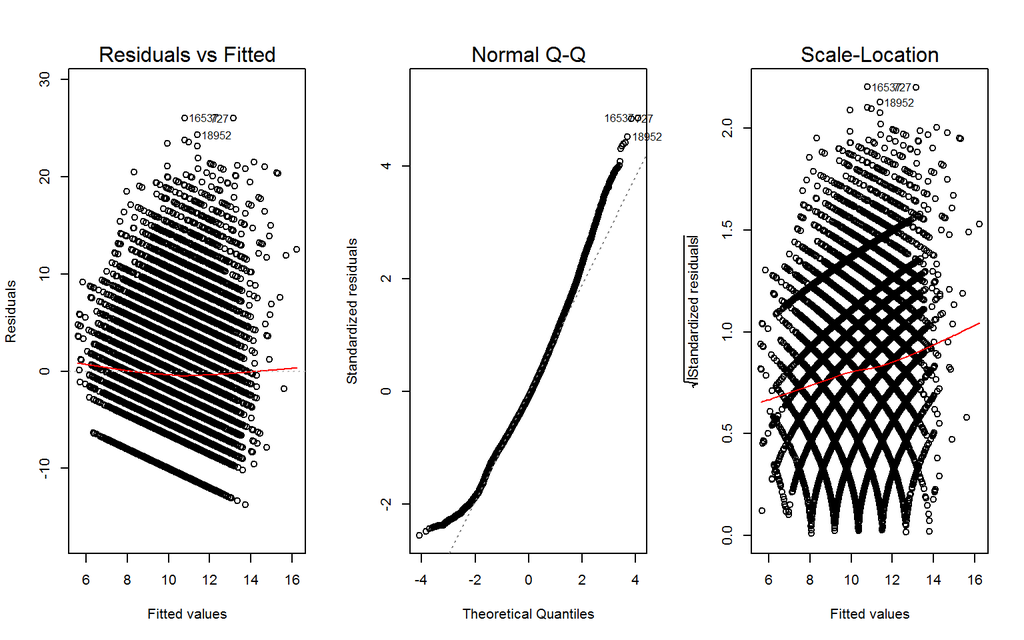

```r
par(mfrow=c(1,3))
for(i in 1:3) plot(modell2,i)
```

## Bonus: grafische Darstellung

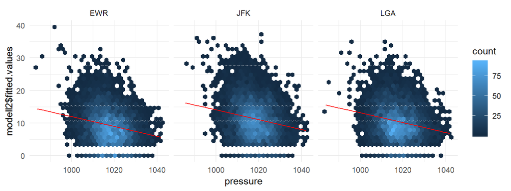

```r
weather_cor  %>%
  filter(!is.na(pressure), !is.na(wind_speed)) %>%
  ggplot(aes(x=pressure, y=modell2$fitted.values)) +
    geom_hex(aes(y=wind_speed)) +
    geom_line(color="red") +
    facet_wrap(.~origin) +
    theme_minimal()
```

## Residuen und vorhergesagte Werte

Die Residuen werden im lm-Objekt unter `residuals` und die prädizierten Werte unter `fitted.values` gespeichert.

```r
weather_res <- weather_cor %>%
  filter(!is.na(pressure), !is.na(wind_speed)) %>%
  mutate(
    res_m1 = modell1$residuals,
    fit_m1 = modell1$fitted.values,
    res_m2 = modell2$residuals,
    fit_m2 = modell2$fitted.values,
  ) %>%
  gather(key, value, res_m1:fit_m2) %>%
  separate(key, c("type","model")) %>%
  spread(type, value)
```

## Nützlich zB für eigene grafische Inspektionen

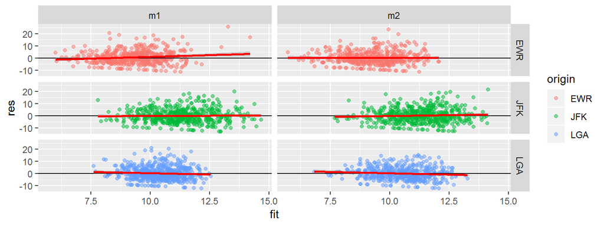

```r
weather_res %>%
  sample_n(3000) %>%
  ggplot(aes(x=fit, y=res)) +
    geom_point(aes(color=origin), alpha=0.5) +
    geom_hline(yintercept=0) +
    geom_smooth(method = "lm", color="red") +
    facet_grid(origin~model)
```

## Was kommt nach `lm()`?

**Nutze `lme4::lmer()` für Mehrebenenmodelle**

Die *formula* kann hier mit **random effects** ergänzt werden in der Form:

```
AV ~
fix eff + (
rand eff|
nesting factor)
```

**Nutze `glm()` für generalisierte lineare Modelle**

Über das zusätzliche *Attribut* **`family`** wird die Link-Funktion ausgewählt.

zB.: `binomial` für logistische oder `poisson` für Poisson-Regressionen

## Ein kleiner Blick in die Möglichkeiten Rs

## Abschlussübung

Bis jetzt nur Analysen, welche auch mit *SPSS* möglich sind.

**Aber**: Voraussetzungen für ALM sind häufig verletzt - da gibt es doch sicher etwas in R

Methoden in [Introduction to Robust Estimating and Hypothesis Testing](https://www.sciencedirect.com/book/9780123869838/introduction-to-robust-estimation-and-hypothesis-testing) von Rand Wilcox im package `WRS2`

1. Finde und nutze die adäquate Funktion um auf robuste Art für den Datensatz `DAAG::cps3` zu überprüfen, ob sich die Personen *mit Einkommen* aufgrund *Familienstand* und *Schulabschluss* in der Höhe des *Einkommens 1978* unterscheiden.
2. Unterscheidet sich Lösung von Ergebnis basierend auf ALM?

## Lösung (1/2)

```r
DAAG::cps3 %>%
  filter(re78 > 0) %>%
  mutate_at(vars(marr, nodeg), factor) %>%
  WRS2::t2way(re78 ~ marr * nodeg, data = .)
```

```
## Call:
## WRS2::t2way(formula = re78 ~ marr * nodeg, data = .)
##
##              value p.value
## marr       13.6732   0.001
## nodeg       5.8136   0.018
## marr:nodeg  0.0433   0.836
```

Alternativ wäre auch two-way ANOVA mit Median und Bootstrap in der Funktion `WRS2::pbad2way()` möglich

## Lösung (2/2)

```r
DAAG::cps3 %>%
  filter(re78 > 0) %>%
  mutate_at(vars(marr, nodeg), factor) %>%
  lm(re78 ~ marr * nodeg, data = .) %>%
  anova()
```

```
## Analysis of Variance Table
##
## Response: re78
##             Df     Sum Sq    Mean Sq F value    Pr(>F)
## marr         1 1.0699e+09 1069929529 23.1724 2.267e-06 ***
## nodeg        1 4.0170e+08  401704709  8.7001  0.003411 **
## marr:nodeg   1 5.9482e+06    5948177  0.1288  0.719885
## Residuals  327 1.5098e+10   46172624
## ---
## Signif. codes:  0 '***' 0.001 '**' 0.01 '*' 0.05 '.' 0.1 ' ' 1
```

## Hausübung

Finden Sie Daten (eigene oder [hier](https://vincentarelbundock.github.io/Rdatasets/datasets.html) für Überblick frei verfügbarer)

Überlegen Sie sich eine Fragestellung basierend auf der Datenbeschreibung

Versuchen Sie die Frage zu beantworten

Präsentieren Sie die Lösung auch deskriptiv und graphisch

Dokumentieren Sie gesamten Prozess als RMarkdown

Schicken Sie das Ergebnis an b.piskernik@gmail.com

## Ressourcen

[StatsExchange](https://stats.stackexchange.com/)

[R-bloggers](https://www.r-bloggers.com)

[RStudio Packages](https://www.rstudio.com/products/rpackages/)

mein Blog

## Danke für Ihre Aufmerksamkeit!